# visualise eu tasks

Team D

2022-03-18

```r
library(tidyverse)
```

```r
library(tidygraph)
library(ggraph)
library(igraph)
```

#### (1)Import data

```r
eu_nodes <- read_table("email-Eu-core-department-labels.txt.gz", col_names = FALSE)
names(eu_nodes) <- c("id", "depts")
eu_edges <- read_table("email-Eu-core.txt.gz", col_names = FALSE)
names(eu_edges) <- c("from", "to")
```

#### (2) Add 1 to every person identifier

```r
#edge tibble
eu_edges <- eu_edges |>
  mutate(from = from + 1, to = to + 1)

#node tibble
eu_nodes <- eu_nodes |>
  mutate(id = id + 1)
```

#### (3) Assemble a `tbl_graph` called `eu_netw` from the tibbles.

```r
eu_netw <-
  tbl_graph(
  nodes = eu_nodes,
  edges = eu_edges
) |>
  print()
```

```
## # A tbl_graph: 1005 nodes and 25571 edges
## #
## # A directed multigraph with 20 components
## #
## # Node Data: 1,005 x 2 (active)
##      id depts
##   <dbl> <dbl>
## 1     1     1
## 2     2     1
## 3     3    21
## 4     4    21
## 5     5    21
## 6     6    25
## # ... with 999 more rows
## #
## # Edge Data: 25,571 x 2
##    from    to
##   <int> <int>
## 1     1     2
## 2     3     4
## 3     3     5
## # ... with 25,568 more rows
```

#### (4) Plot the complete network with `ggraph`. Do you find the result useful? Why or why not? Does changing the layout help?

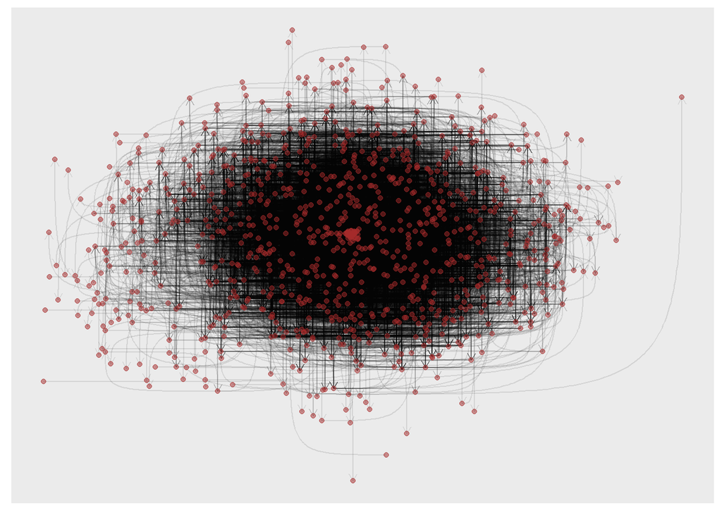

```r
ggraph(eu_netw, layout = "kk") +
  geom_edge_bend(
    alpha = 0.1,
    arrow = arrow(length = unit(2, "mm"))
  ) +
  geom_node_point(colour = "brown", alpha = 0.5)
```

ANS:  
The graph is not really informative. There are many overlaps of vertices in the graph, and given that both points and lines are all of the same color, red and black respectively, there is a limited number of distinct lines. Additionally, the points does not have any labels and it is not conveyed which point refers to which `id`. In other words, it is difficult and nearly impossible to understand any relationships from the graph above. Changing the layout makes does not improve the graph, this is because it does not resolve the problem of (1) lack of information for each point, (2) overlap of lines and (3) lines remain indistinguishable.

#### (5) Contracting network

```r
contracted_eu_igraph <-
  eu_netw |>
  as.igraph() |>
  contract(eu_nodes$depts + 1)

vertex_attr(contracted_eu_igraph, "depts") <-
  0:(gorder(contracted_eu_igraph) - 1)

contracted_directed_netw <-
  as_tbl_graph(contracted_eu_igraph) |>
  convert(to_simple) |>
  activate(edges) |>
  mutate(weight = lengths(.tidygraph_edge_index)) |>
  print()
```

```
## # A tbl_graph: 42 nodes and 1203 edges
## #
## # A directed simple graph with 1 component
## #
## # Edge Data: 1,203 x 5 (active)
##    from    to .tidygraph_edge_index .orig_data         weight
##   <int> <int> <list>                <list>              <int>
## 1     1     2 <int [35]>            <tibble [35 x 2]>      35
## 2     1     3 <int [1]>             <tibble [1 x 2]>        1
## 3     1     4 <int [8]>             <tibble [8 x 2]>        8
## 4     1     5 <int [123]>           <tibble [123 x 2]>    123
## 5     1     6 <int [26]>            <tibble [26 x 2]>      26
## 6     1     7 <int [5]>             <tibble [5 x 2]>        5
## # ... with 1,197 more rows
## #
## # Node Data: 42 x 2
##   depts .tidygraph_node_index
##   <int>                 <int>
## 1     0                     1
## 2     1                     2
## 3     2                     3
## # ... with 39 more rows
```

#### (6) Make a plot of the contracted network. Do you find the results useful?

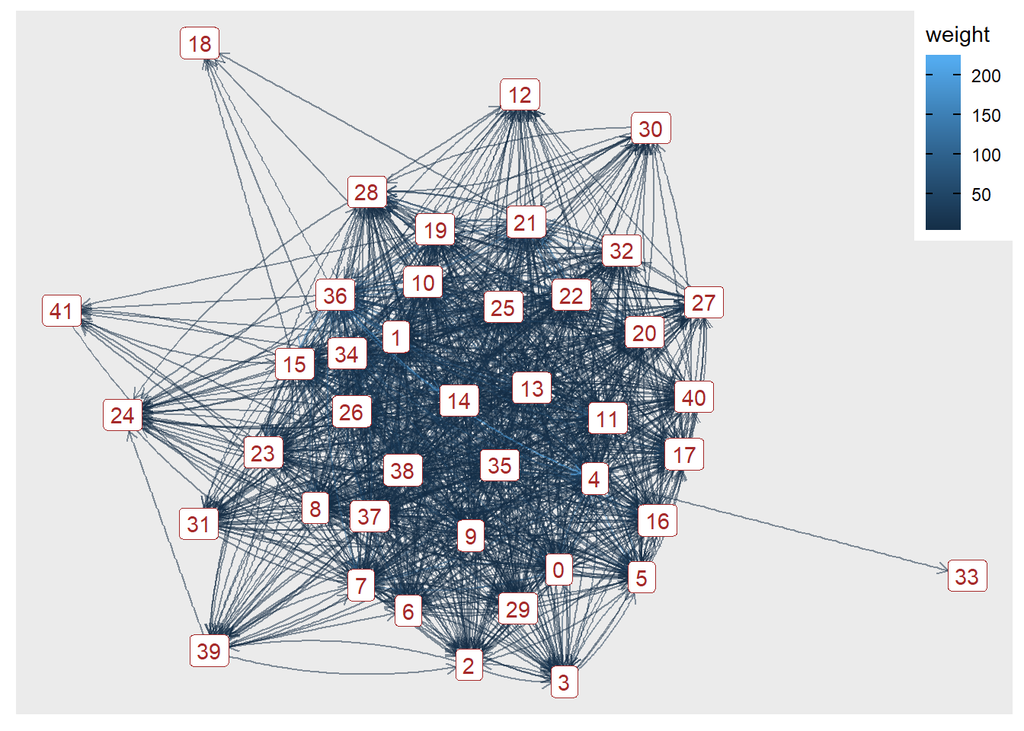

```r
ggraph(contracted_directed_netw, layout = "stress") +
  geom_edge_fan(
    aes(colour = weight, end_cap = label_rect(node2.depts)),
    alpha = 0.5,
    arrow = arrow(length = unit(0.2, "cm"))
  ) +
  geom_node_label(aes(label = depts), colour = "brown") +
  theme(legend.position = c(1, 1), legend.justification = c(1, 1))
```

The graph is not very informative and is not that useful. While the points are now labelled, the lines connecting the points still overlap one another, rendering them indistinguishable from one another.

#### (7) Create an version of `contracted_directed_netw` from task (5) and turn it into a network. Then, append a column `weight`.

```r
# Creating an undirected version of contracted_directed_netw
contracted_undirected_netw <-
  contracted_directed_netw |>
  convert(to_undirected)

# Converting it into a simple network
contracted_simple_netw <-
  contracted_undirected_netw |>
  convert(to_simple)

# Appending the column weight
undirected_simple_netw <- contracted_simple_netw |>
  activate(edges) |>
  mutate(weight = map_dbl(.orig_data, ~ sum(pull(., weight)))) |>
  print()
```

```
## # A tbl_graph: 42 nodes and 641 edges
## #
## # An undirected simple graph with 1 component
## #
## # Edge Data: 641 x 5 (active)
##    from    to .tidygraph_edge_index .orig_data       weight
##   <int> <int> <list>                <list>            <dbl>
## 1     1     2 <int [2]>             <tibble [2 x 4]>     54
## 2     1     3 <int [2]>             <tibble [2 x 4]>      3
## 3     1     4 <int [2]>             <tibble [2 x 4]>     17
## 4     1     5 <int [2]>             <tibble [2 x 4]>    273
## 5     1     6 <int [2]>             <tibble [2 x 4]>     48
## 6     1     7 <int [2]>             <tibble [2 x 4]>     16
## # ... with 635 more rows
## #
## # Node Data: 42 x 2
##   depts .tidygraph_node_index
##   <int>                 <int>
## 1     0                     1
## 2     1                     2
## 3     2                     3
## # ... with 39 more rows
```

#### (8) Obtain a new network that contains the hierarchy of the dendrogram.

```r
hierarchy <-
  undirected_simple_netw |>
  convert(to_hierarchical_clusters, weights = weight) |>
  na.omit() |>
  print()
```

```
## # A tbl_graph: 83 nodes and 82 edges
## #
## # A rooted tree
## #
## # Edge Data: 82 x 2 (active)
##    from    to
##   <int> <int>
## 1     4     2
## 2     4     3
## 3     8     6
## 4     8     7
## 5     9     5
## 6     9     8
## # ... with 76 more rows
## #
## # Node Data: 83 x 5
##   height leaf  members .tidygraph_node_index depts
##    <dbl> <lgl>   <int>                 <int> <int>
## 1      0 TRUE        1                    34    33
## 2      0 TRUE        1                    22    21
## 3      0 TRUE        1                    29    28
## # ... with 80 more rows
```

#### (9) Plot dendrogram

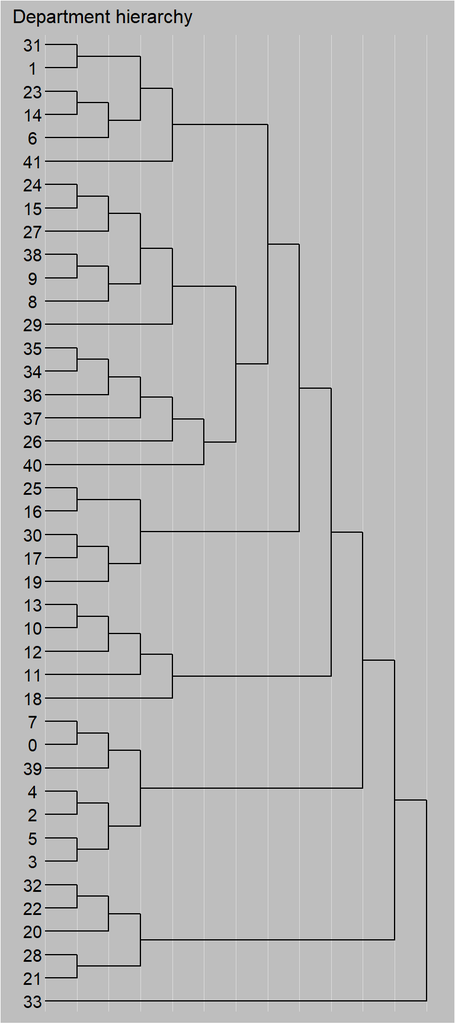

```r
layout <- create_layout(hierarchy, "dendrogram")
ggraph(layout) +
  geom_edge_elbow() +
  geom_node_text(aes(label = depts),
                 nudge_y = -0.4) +
  coord_flip() +
  labs(title = "Department hierarchy") +
  theme(
    plot.background = element_rect(fill = "grey"),
    panel.background = element_rect(linetype = "solid",
                                    fill = "grey"),
    panel.grid.major.y = element_blank(),
    panel.grid.major.x = element_line(size = .05, colour = "gray86"),
    title = element_text(size = 10)
  ) +
  scale_y_continuous(breaks = seq(0, 12, 1)) +
  scale_x_continuous(expand = expansion(0.01))
```

#### (10) Briefly reflect on the advantages and disadvantages of representing the network data with the dendrogram of figure 1 compared to the network figure you produced in task (6).

ANS:  
The advantage of representing the network data with dendrogram is that the links between the nodes are explicit, effectively and clearly informing viewers which departments often email one another. This graph thus conveys information a lot more clearly as compared to the figure in task (6), where lines connecting the points are mostly indistinguishable. Another advantage of dendrogram is that there are various levels, in this case 13 levels, of which might potentially provide information regarding the hierarchical structure of departments within this network. As the figure in task (6) does not have this structure, it cannot convey such information.

The disadvantage of using a dendrogram in comparison to the figure in task (6) is that the dendrogram is undirected. This means it is unable to convey detailed information such as which department sends the emails, and the information is more generalized.